# Annotation of mobile genetic elements

Query: VariantCaller_final_polish

Produced with bacannot pipeline

04 September 2020

# 1 About

Mobile genetic elements (MGEs) are a type of genetic materials that can move around within a genome, or that can be transferred from one species or replicon to another. Newly acquired genes through this mechanism can increase fitness by gaining new or additional functions. On the other hand, MGEs can also decrease fitness by introducing disease-causing alleles or mutations. For instance, prophages are bacteriophages that have been inserted and integrated into the bacterial chromosome or plasmid. It is the latent form of a phage. ICEs (integrative and conjugative elements), on the other hand, are integrative mobile genetic elements that encode a conjugation machinery. They can confer selective advantages and can also encode resistance determinants and virulence factors.

In this context, this pipeline automatically annotates prophage sequences and proteins using [PHAST](https://phaster.ca) database and phigaro software. While [ICEberg](https://bioinfo-mml.sjtu.edu.cn/ICEberg2/index.php) database is used to annotate ICEs.

About the BLASTs:

> The results used to create this report are under the directories called `prophages` and `ICEs` in the output folder of the query VariantCaller_final_polish.

# 2 Genomic Islands prediction

Genomic Islands (GIs) are annotated with [islandPath](https://github.com/brinkmanlab/islandpath). Its results are all incorporated into JBrowse output and are drawn in yellow. This result shall be seen by using the genome browser provided in the `jbrowse` directory inside the query main output directory. These genome browser might be opened with [JBrowse Desktop](https://jbrowse.org/docs/jbrowse_desktop.html) sofwtare. Also, a BED file containing the genomic positions of predicted GIs can be found in the `predicted_GIs` directory under the main output directory.

# 3 Phigaro prediction

All prophages annotated using phigaro are better shown in its own html report file. The genomic regions predicted as putative prophage sequences are summarized in Table 3.1.

- Check it out at:
  - Dir: `/Volumes/falmeida1TB/bacannot_teste/teste/VariantCaller_final_polish/prophages/phigaro`
  - HTML: `/Volumes/falmeida1TB/bacannot_teste/teste/VariantCaller_final_polish/prophages/phigaro/VariantCaller_final_polish_phigaro.html`

> It is worthy taking notes of prophage’s genomic regions for a better exploration using the JBROWSE genome browser provided. This genome browser was automatically created (stored in a dir called `jbrowse`) and can be visualized with [JBROWSE desktop](https://github.com/GMOD/jbrowse).

Table 3.1: Putative prophage sequences annotated with phigaro software

|  | scaffold | begin | end | transposable | taxonomy | vog |
| --- | --- | --- | --- | --- | --- | --- |
| 1 | 5_arrow_pilon | 36558 | 56247 | False | Siphoviridae / Podoviridae | VOG1309, VOG6520, VOG7616, VOG5443, VOG0901, VOG4829, VOG5994, VOG0107, VOG0189, VOG2086, VOG0299, VOG4618, VOG6152, VOG4705, VOG6965, VOG10343, VOG0227 |
| 2 | 13_arrow_pilon | 5402 | 18674 | False | Myoviridae | VOG0823, VOG10933, VOG4829, VOG2186, VOG4566, VOG3607, VOG4556, VOG4691, VOG2795, VOG8497, VOG0227, VOG0227, VOG6042, VOG0221, VOG9438, VOG8306 |

# 4 PHAST database annotation

## 4.1 Against the whole genome

All prophage genes from PHAST database that had good alignments to the query genome (whole genome) are summarised in Table 4.1. We report both annotations using the predicted genes and the whole genome because Prokka uses prodigal to predicted genes which may miss some genomes.

Table 4.1: Prophage genes using the PHAST database via BLASTx against the whole genome

|  | Contig | Start | End | Strand | Product | Coverage_aln | Gaps | Coverage % | Identity % | Database | Ref. Accession | Description |
| --- | --- | --- | --- | --- | --- | --- | --- | --- | --- | --- | --- | --- |
| 1 | 2_arrow_pilon | 98591 | 99739 | + | IS30 transposase | 1-383/383 | 0/0 | 100 | 99.7 | phast | NP_418704.1 | PROPHAGE_Escher_MG1655-gi\|16132105\|ref\|NP_418704.1\| IS30 transposase [Escherichia coli str. K-12 substr. MG1655] |
| 2 | 3_arrow_pilon | 28696 | 29829 | + | predicted transposase | 1-378/378 | 0/0 | 100 | 97.6 | phast | NP_417941.1 | PROPHAGE_Escher_MG1655-gi\|16131356\|ref\|NP_417941.1\| predicted transposase [Escherichia coli str. K-12 substr. MG1655] |
| 3 | 5_arrow_pilon | 18650 | 19663 | + | IS5 transposase and trans activator | 1-338/338 | 0/0 | 100 | 100 | phast | NP_416535.1 | PROPHAGE_Escher_MG1655-gi\|16129971\|ref\|NP_416535.1\| IS5 transposase and trans-activator [Escherichia coli str. K-12 substr. MG1655] |
| 4 | 5_arrow_pilon | 51302 | 50325 | - | IS5 transposase and trans activator | 12-337/338 | 0/0 | 96.45 | 99.1 | phast | NP_416535.1 | PROPHAGE_Escher_MG1655-gi\|16129971\|ref\|NP_416535.1\| IS5 transposase and trans-activator [Escherichia coli str. K-12 substr. MG1655] |
| 5 | 4_arrow_pilon | 5704 | 6837 | + | predicted transposase | 1-378/378 | 0/0 | 100 | 97.6 | phast | NP_417941.1 | PROPHAGE_Escher_MG1655-gi\|16131356\|ref\|NP_417941.1\| predicted transposase [Escherichia coli str. K-12 substr. MG1655] |
| 6 | 7_arrow_pilon | 58650 | 57103 | - | putative ATP dependent protease | 1-516/516 | 0/0 | 100 | 98.8 | phast | NP_312727.1 | PROPHAGE_Escher_Sakai-gi\|15833954\|ref\|NP_312727.1\| putative ATP-dependent protease [Escherichia coli O157:H7 str. Sakai] |
| 7 | 8_arrow_pilon | 13125 | 14138 | + | IS5 transposase and trans activator | 1-338/338 | 0/0 | 100 | 100 | phast | NP_416498.1 | PROPHAGE_Escher_MG1655-gi\|16129935\|ref\|NP_416498.1\| IS5 transposase and trans-activator [Escherichia coli str. K-12 substr. MG1655] |
| 8 | 9_arrow_pilon | 46247 | 45234 | - | IS5 transposase and trans activator | 1-338/338 | 0/0 | 100 | 100 | phast | NP_416535.1 | PROPHAGE_Escher_MG1655-gi\|16129971\|ref\|NP_416535.1\| IS5 transposase and trans-activator [Escherichia coli str. K-12 substr. MG1655] |
| 9 | 12_arrow_pilon | 44775 | 43627 | - | IS30 transposase | 1-383/383 | 0/0 | 100 | 100 | phast | NP_418704.1 | PROPHAGE_Escher_MG1655-gi\|16132105\|ref\|NP_418704.1\| IS30 transposase [Escherichia coli str. K-12 substr. MG1655] |
| 10 | 17_arrow_pilon | 5279 | 4170 | - | IS186 transposase | 1-370/370 | 0/0 | 100 | 100 | phast | NP_416895.2 | PROPHAGE_Escher_MG1655-gi\|90111427\|ref\|NP_416895.2\| IS186 transposase [Escherichia coli str. K-12 substr. MG1655] |

[output cut: 8 more lines]

## 4.2 Against the predicted genes

All prophage genes from PHAST database that had good alignments to the genes of the query genome are summarised in Table 4.2. The protein sequences of these genes were aligned against the gene sequences predicted by Prokka via BLASTp.

> Unfortunately, PHASTER database have no searchable interface to visualize its prophages. Therefore, this table has no links to external sources.

Table 4.2: Prophage genes annotated using PHAST database via BLASTp

|  | Prophage of origin | Description | Query protein | Product | Genomic Position |
| --- | --- | --- | --- | --- | --- |
| 1 | PHAGE_Entero_cdtI_NC_009514 | PHAGE_Entero_cdtI_NC_009514-gi\|148609424\|ref\|YP_001272555.1\| Repressor [Enterobacteria phage cdtI] | LFFGOINE_00919 | Repressor | 13_arrow_pilon:7639-7839 |
| 2 | PHAGE_Entero_HK97_NC_002167 | PHAGE_Entero_HK97_NC_002167-gi\|9634180\|ref\|NP_037719.1\| Gp29 [Enterobacteria phage HK97] | LFFGOINE_00928 | Gp29 | 13_arrow_pilon:12904-13506 |
| 3 | PHAGE_Entero_P1_NC_005856 | PHAGE_Entero_P1_NC_005856-gi\|46401643\|ref\|YP_006488.1\| InsA [Enterobacteria phage P1] | LFFGOINE_00220 | InsA | 2_arrow_pilon:86333-86608 |
| 4 | PHAGE_Entero_P1_NC_005856 | PHAGE_Entero_P1_NC_005856-gi\|46401643\|ref\|YP_006488.1\| InsA [Enterobacteria phage P1] | LFFGOINE_00249 | InsA | 2_arrow_pilon:107588-107863 |
| 5 | PHAGE_Entero_P1_NC_005856 | PHAGE_Entero_P1_NC_005856-gi\|46401643\|ref\|YP_006488.1\| InsA [Enterobacteria phage P1] | LFFGOINE_01058 | InsA | 17_arrow_pilon:216-491 |
| 6 | PHAGE_Entero_P1_NC_005856 | PHAGE_Entero_P1_NC_005856-gi\|46401643\|ref\|YP_006488.1\| InsA [Enterobacteria phage P1] | LFFGOINE_01349 | InsA | 23_arrow_pilon:21655-21930 |
| 7 | PHAGE_Entero_P1_NC_005856 | PHAGE_Entero_P1_NC_005856-gi\|46401643\|ref\|YP_006488.1\| InsA [Enterobacteria phage P1] | LFFGOINE_01417 | InsA | 25_arrow_pilon:21080-21355 |
| 8 | PHAGE_Entero_SfV_NC_003444 | PHAGE_Entero_SfV_NC_003444-gi\|19548988\|ref\|NP_599052.1\| tail protein [Enterobacteria phage SfV] | LFFGOINE_00926 | tail protein | 13_arrow_pilon:11528-12112 |
| 9 | PHAGE_Salmon_118970_sal3_NC_031940 | PHAGE_Salmon_118970_sal3_NC_031940-gi\|100033\|ref\|YP_009324744.1\| hypothetical protein [Salmonella phage 118970_sal3] | LFFGOINE_00415 | hypothetical protein | 5_arrow_pilon:56564-56797 |
| 10 | PHAGE_Salmon_Fels_2_NC_010463 | PHAGE_Salmon_Fels_2_NC_010463-gi\|169936026\|ref\|YP_001718725.1\| DNA-invertase [Salmonella phage Fels-2] | LFFGOINE_00931 | DNA invertase | 13_arrow_pilon:14300-14854 |

[output cut: 1719 more lines]

# 5 ICEberg database annotation

## 5.1 Analysis of full-length ICEs

Full-length ICEs are available at [ICEberg database](https://bioinfo-mml.sjtu.edu.cn/ICEberg/download.html) in nucleotide fastas while the proteins found inside these ICEs are in protein fastas. The full-length ICEs are very difficult to be completely found in new genomes, thus they are scanned without coverage or identity thresholds. The filtering and selection of these is up to you.

We have found a total of 0 alignments in the query genome, check it out in table 5.1.

Table 5.1: Alignment of full-length ICEs to the query genome via BLASTn

|  | Contig | Start | End | Strand | Product | Coverage_aln | Gaps | Coverage % | Identity % | Database | Ref. Accession | Description | NA | NA |
| --- | --- | --- | --- | --- | --- | --- | --- | --- | --- | --- | --- | --- | --- | --- |

## 5.2 Analysis of ICE’s proteins

### 5.2.1 Against the whole genome

All ICE’s proteins from ICEberg database that had good alignments to the query genome (whole genome) are summarised in Table 5.2. We report both annotations using the predicted genes and the whole genome because Prokka uses prodigal to predicted genes which may miss some genomes.

> Take note: The fact that the genome possess some proteins from ICEs does not necessarily means that the ICE is present in the genome. Please, check the number of proteins that the ICE of origin posses in the [ICEberg database list of ICEs](https://bioinfo-mml.sjtu.edu.cn/ICEberg2/browse_result.php?type=alpha&alpha=100), and them infer based one the alignments you see if your genome have or not one ICE in it.

Table 5.2: ICE genes annotated from ICEberg database via BLASTx

|  | Contig | Start | End | Strand | ICEberg of origin | Coverage_aln | Gaps | Coverage % | Identity % | Database | Ref. Accession | Product / Gene | Description |
| --- | --- | --- | --- | --- | --- | --- | --- | --- | --- | --- | --- | --- | --- |
| 1 | 17_arrow_pilon | 410 | 910 | + | 288 | 1-167/167 | 0/0 | 100 | 97 | ICEberg | CAD06777.1 | insertion element IS1 protein InsB Salmonella enterica subsp. enterica serovar Typhi | ICEberg\|288 gi\|16505427\|emb\|CAD06777.1\| insertion element IS1 protein InsB [Salmonella enterica subsp. enterica serovar Typhi] |
| 2 | 23_arrow_pilon | 21736 | 21236 | - | 288 | 1-167/167 | 0/0 | 100 | 97 | ICEberg | CAD06777.1 | insertion element IS1 protein InsB Salmonella enterica subsp. enterica serovar Typhi | ICEberg\|288 gi\|16505427\|emb\|CAD06777.1\| insertion element IS1 protein InsB [Salmonella enterica subsp. enterica serovar Typhi] |
| 3 | 25_arrow_pilon | 21274 | 21774 | + | 288 | 1-167/167 | 0/0 | 100 | 97 | ICEberg | CAD06777.1 | insertion element IS1 protein InsB Salmonella enterica subsp. enterica serovar Typhi | ICEberg\|288 gi\|16505427\|emb\|CAD06777.1\| insertion element IS1 protein InsB [Salmonella enterica subsp. enterica serovar Typhi] |

### 5.2.2 Against the predicted genes

All query genes predicted by Prokka that have a match in ICEberg database are shown in Table 5.3. It is summarised the ICE id and all its genes that were found in the query genome. All of them are linked to the database for further investigations.

> Take note: The fact that the genome possess some proteins from ICEs does not necessarily means that the ICE is present in the genome. Please, check the number of proteins that the ICE of origin posses in the [ICEberg database list of ICEs](https://bioinfo-mml.sjtu.edu.cn/ICEberg2/browse_result.php?type=alpha&alpha=100), and them infer based one the alignments you see if your genome have or not one ICE in it.

Users are advised to also use the [ICEfinder](https://bioinfo-mml.sjtu.edu.cn/ICEberg2/tools.html) tool to predict genomic position of known ICEs since we are not allowed to include this step under this pipeline.

Table 5.3: ICE genes annotated from ICEberg database via BLASTp

|  | Query Protein | ICEberg of origin | Ref. Accession | Product / Gene | Description | Genomic Position |
| --- | --- | --- | --- | --- | --- | --- |
| 1 | LFFGOINE_00220 | 288 | CAD06778.1 | insertion element IS1 protein Salmonella enterica subsp. enterica serovar Typhi | ICEberg\|288 gi\|16505428\|emb\|CAD06778.1\| insertion element IS1 protein [Salmonella enterica subsp. enterica serovar Typhi] | 2_arrow_pilon:86333-86608 |
| 2 | LFFGOINE_00249 | 288 | CAD06778.1 | insertion element IS1 protein Salmonella enterica subsp. enterica serovar Typhi | ICEberg\|288 gi\|16505428\|emb\|CAD06778.1\| insertion element IS1 protein [Salmonella enterica subsp. enterica serovar Typhi] | 2_arrow_pilon:107588-107863 |
| 3 | LFFGOINE_01058 | 288 | CAD06778.1 | insertion element IS1 protein Salmonella enterica subsp. enterica serovar Typhi | ICEberg\|288 gi\|16505428\|emb\|CAD06778.1\| insertion element IS1 protein [Salmonella enterica subsp. enterica serovar Typhi] | 17_arrow_pilon:216-491 |
| 4 | LFFGOINE_01278 | 288 | CAD06768.1 | hypothetical protein Salmonella enterica subsp. enterica serovar Typhi | ICEberg\|288 gi\|16505418\|emb\|CAD06768.1\| hypothetical protein [Salmonella enterica subsp. enterica serovar Typhi] | 21_arrow_pilon:18027-18284 |
| 5 | LFFGOINE_01349 | 288 | CAD06778.1 | insertion element IS1 protein Salmonella enterica subsp. enterica serovar Typhi | ICEberg\|288 gi\|16505428\|emb\|CAD06778.1\| insertion element IS1 protein [Salmonella enterica subsp. enterica serovar Typhi] | 23_arrow_pilon:21655-21930 |
| 6 | LFFGOINE_01417 | 288 | CAD06778.1 | insertion element IS1 protein Salmonella enterica subsp. enterica serovar Typhi | ICEberg\|288 gi\|16505428\|emb\|CAD06778.1\| insertion element IS1 protein [Salmonella enterica subsp. enterica serovar Typhi] | 25_arrow_pilon:21080-21355 |

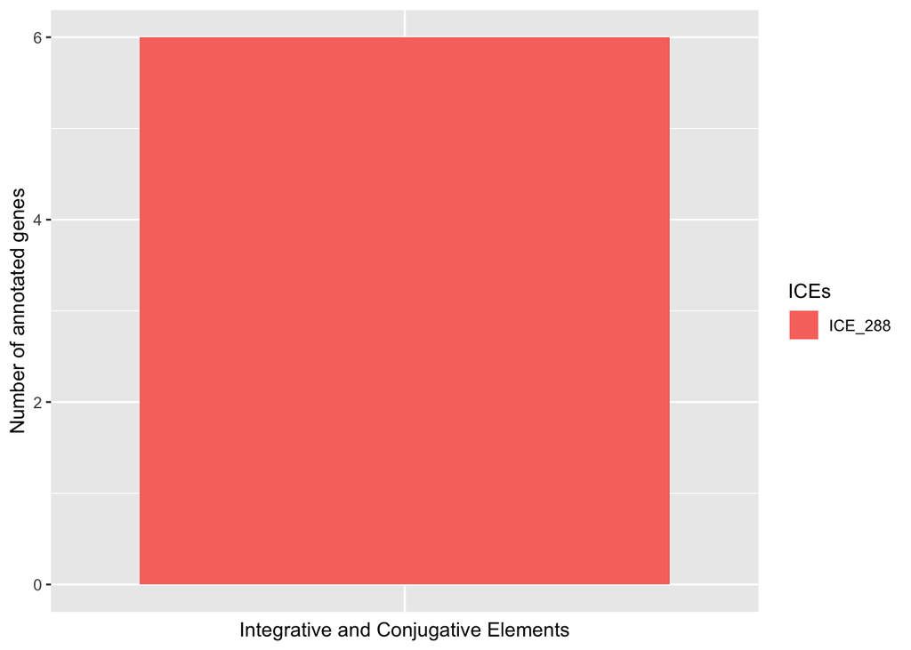

Figure 5.1: The number of genes from known ICEs (from [ICEberg](https://bioinfo-mml.sjtu.edu.cn/ICEberg2/index.php)) found in the query genome